# Dự đoán tỷ lệ tội phạm bạo lực trong các cộng đồng Hoa Kỳ

## 18.3 Ngoại lai của mức lương

Quy tắc 1,5 × IQR xác định 10 mức lương nằm xa phần trung tâm của phân phối. Đây là các ngoại lai về mặt thống kê, nhưng không đồng nghĩa với lỗi dữ liệu. Vì vậy, các quan sát này được kiểm tra thêm dựa trên chức danh, cấp kinh nghiệm, đơn vị tiền tệ và các đặc điểm công việc.

Bảng 4. Các quan sát được xác định là ngoại lai theo quy tắc 1,5 × IQR

| Năm | Kinh nghiệm | Chức danh chuẩn hóa | Lương (USD) | Hình thức làm việc |
| --- | --- | --- | --- | --- |
| 2021 | Executive-level / Director | Principal Data Engineer | $600,000 | Fully remote (100%) |
| 2020 | Mid-level / Intermediate | Research Scientist | $450,000 | On-site (0%) |
| 2021 | Mid-level / Intermediate | Financial Data Analyst | $450,000 | Fully remote (100%) |
| 2021 | Mid-level / Intermediate | Applied Machine Learning Scientist | $423,000 | Hybrid (50%) |
| 2021 | Executive-level / Director | Principal Data Scientist | $416,000 | Fully remote (100%) |
| 2020 | Senior-level / Expert | Data Scientist | $412,000 | Fully remote (100%) |
| 2022 | Senior-level / Expert | Lead Data Analyst | $405,000 | Fully remote (100%) |
| 2022 | Senior-level / Expert | Applied Data Scientist | $380,000 | Fully remote (100%) |
| 2020 | Executive-level / Director | Director of Data Science | $325,000 | Fully remote (100%) |
| 2022 | Executive-level / Director | Data Engineer | $324,000 | Fully remote (100%) |

Có 10 quan sát vượt ngưỡng trên $283,864 và không có quan sát nào thấp hơn ngưỡng dưới. Trong số này, 7 quan sát thuộc cấp Senior hoặc Executive và 8 quan sát là các vị trí Fully remote; các trường hợp còn lại chủ yếu tập trung ở những chức danh đòi hỏi chuyên môn cao. Cả 10 ngoại lai đều thuộc North America, phù hợp với kết quả EDA cho thấy khu vực này có mặt bằng lương danh nghĩa cao hơn phần còn lại của mẫu; sự tập trung ở Fully remote cũng cần được đặt trong bối cảnh hình thức này đã chiếm 61,2% toàn mẫu và thường đi cùng vị trí cấp cao hoặc khu vực lương cao. Các giá trị đều dương, sử dụng đơn vị tiền tệ hợp lệ và không cho thấy dấu hiệu rõ ràng của lỗi nhập liệu, nên được giữ nguyên trong dữ liệu.

# 19 Phân tích khám phá dữ liệu

## 19.1 Cấu trúc mẫu

Bảng 5. Tần số và tỷ lệ của các biến phân loại

| Đặc điểm | Nhóm | Số quan sát | Tỷ lệ (%) |
| --- | --- | --- | --- |
| Năm | 2020 | 72 | 12,7 |
| Năm | 2021 | 215 | 38,1 |
| Năm | 2022 | 278 | 49,2 |
| Kinh nghiệm | Entry-level / Junior | 88 | 15,6 |
| Kinh nghiệm | Mid-level / Intermediate | 208 | 36,8 |
| Kinh nghiệm | Senior-level / Expert | 243 | 43,0 |
| Kinh nghiệm | Executive-level / Director | 26 | 4,6 |
| Nhóm tuyển dụng | Full-time | 546 | 96,6 |
| Nhóm tuyển dụng | Other employment arrangements | 19 | 3,4 |
| Hình thức làm việc | On-site (0%) | 121 | 21,4 |
| Hình thức làm việc | Hybrid (50%) | 98 | 17,3 |
| Hình thức làm việc | Fully remote (100%) | 346 | 61,2 |
| Quy mô công ty | Small | 82 | 14,5 |
| Quy mô công ty | Medium | 290 | 51,3 |
| Quy mô công ty | Large | 193 | 34,2 |
| Lĩnh vực nghề nghiệp | Data Science & Research | 195 | 34,5 |
| Lĩnh vực nghề nghiệp | Data Engineering & Architecture | 168 | 29,7 |
| Lĩnh vực nghề nghiệp | Data Analytics & Business Intelligence | 118 | 20,9 |
| Lĩnh vực nghề nghiệp | Machine Learning & AI | 84 | 14,9 |
| Khu vực cư trú | North America | 322 | 57,0 |
| Khu vực cư trú | Europe | 160 | 28,3 |
| Khu vực cư trú | Asia | 60 | 10,6 |
| Khu vực cư trú | Others | 23 | 4,1 |
| Quan hệ địa lý với công ty | Cùng quốc gia | 514 | 91,0 |
| Quan hệ địa lý với công ty | Khác quốc gia | 51 | 9,0 |

Cấu trúc mẫu tập trung rõ ở năm 2022 (49,2%), cấp Senior (43,0%), công ty Medium (51,3%), hình thức Fully remote (61,2%) và North America (57,0%). Full-time chiếm 96,6% số quan sát, còn nhóm `Other employment arrangements` chỉ gồm 19 trường hợp; các thống kê của nhóm này vẫn được trình bày nhưng dễ bị chi phối bởi từng quan sát. Nhóm Executive và `Others` lần lượt có 26 và 23 quan sát, trong khi 91,0% vị trí có người lao động và công ty ở cùng quốc gia. Sự mất cân đối giữa các mức có thể làm giảm độ ổn định của thông tin dự báo và cần được xử lý nhất quán khi mã hóa, điều chuẩn và đánh giá ngoài mẫu.

## 19.2 Thống kê mô tả mức lương

Bảng 6. Thống kê mô tả salary_in_usd

| Thống kê | Giá trị |
| --- | --- |
| Số quan sát | 565 |
| Trung bình | $110,610 |
| Độ lệch chuẩn | $72,281 |
| Nhỏ nhất | $2,859 |
| Q1 | $60,757 |
| Trung vị | $100,000 |
| Q3 | $150,000 |
| IQR | $89,243 |
| Lớn nhất | $600,000 |
| Độ lệch (skewness) | 1,73 |

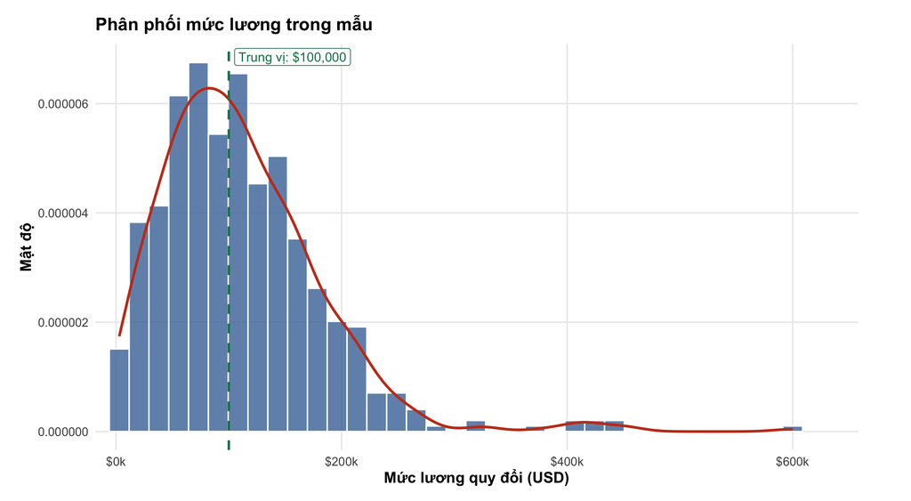

Phân phối mức lương quy đổi sang USD; đường đứt nét biểu diễn trung vị.

Trung bình ($110,610) cao hơn trung vị ($100,000) khoảng $10,600; độ lệch (skewness) bằng 1,73 và mức lớn nhất $600,000 xác nhận đuôi phải kéo dài. Tuy nhiên, 50% quan sát trung tâm đã trải từ $60,757 đến $150,000, với IQR $89,243, nên độ phân tán lớn không chỉ do một vài mức lương cao. Trung vị và IQR vì vậy phản ánh vị trí và độ rộng của phần trung tâm tốt hơn trung bình và độ lệch chuẩn trong các so sánh nhóm. `salary_in_usd` có phân phối lệch phải và chứa một số mức lương cao nhưng hợp lý về mặt nội dung. Đặc điểm này được lưu ý khi xây dựng và đánh giá mô hình, nhưng không tự động dẫn đến việc biến đổi log.

## 19.3 Mức lương theo các đặc điểm công việc

Bảng 7. Thống kê mô tả mức lương theo các nhóm chính

| Đặc điểm | Nhóm | n | Trung bình | Độ lệch chuẩn | Trung vị | Q1–Q3 |
| --- | --- | --- | --- | --- | --- | --- |
| Lĩnh vực nghề nghiệp | Data Science & Research | 195 | $115,791 | $74,561 | $104,702 | $62,058 – $153,084 |
| Lĩnh vực nghề nghiệp | Data Engineering & Architecture | 168 | $117,668 | $71,451 | $109,512 | $69,342 – $160,000 |
| Lĩnh vực nghề nghiệp | Data Analytics & Business Intelligence | 118 | $99,393 | $64,026 | $93,350 | $60,325 – $126,500 |
| Lĩnh vực nghề nghiệp | Machine Learning & AI | 84 | $100,226 | $77,490 | $80,020 | $45,046 – $128,250 |
| Kinh nghiệm | Entry-level / Junior | 88 | $61,643 | $44,396 | $56,500 | $27,505 – $85,426 |
| Kinh nghiệm | Mid-level / Intermediate | 208 | $87,793 | $64,119 | $76,940 | $47,164 – $112,075 |
| Kinh nghiệm | Senior-level / Expert | 243 | $138,375 | $59,956 | $135,000 | $99,532 – $171,881 |
| Kinh nghiệm | Executive-level / Director | 26 | $199,392 | $117,071 | $171,438 | $130,006 – $233,750 |
| Nhóm tuyển dụng | Full-time | 546 | $111,812 | $70,791 | $100,000 | $62,726 – $150,000 |
| Nhóm tuyển dụng | Other employment arrangements | 19 | $76,083 | $103,282 | $31,875 | $13,983 – $100,000 |
| Quy mô công ty | Small | 82 | $77,872 | $63,815 | $65,511 | $41,816 – $100,000 |
| Quy mô công ty | Medium | 290 | $114,807 | $60,779 | $109,640 | $70,822 – $150,214 |
| Quy mô công ty | Large | 193 | $118,214 | $86,753 | $100,000 | $60,000 – $153,667 |
| Hình thức làm việc | On-site (0%) | 121 | $105,785 | $68,393 | $98,158 | $62,000 – $136,000 |
| Hình thức làm việc | Hybrid (50%) | 98 | $80,722 | $57,639 | $68,010 | $50,000 – $99,926 |
| Hình thức làm việc | Fully remote (100%) | 346 | $120,763 | $74,930 | $110,712 | $70,000 – $159,750 |
| Khu vực cư trú | North America | 322 | $145,659 | $70,375 | $135,000 | $100,000 – $174,000 |
| Khu vực cư trú | Europe | 160 | $69,200 | $34,793 | $63,278 | $46,422 – $87,932 |
| Khu vực cư trú | Asia | 60 | $52,156 | $54,233 | $32,712 | $17,766 – $66,083 |
| Khu vực cư trú | Others | 23 | $60,493 | $51,391 | $40,038 | $19,454 – $93,712 |
| Năm | 2020 | 72 | $95,813 | $82,832 | $75,544 | $45,724 – $115,526 |
| Năm | 2021 | 215 | $99,430 | $80,304 | $82,528 | $50,000 – $135,000 |
| Năm | 2022 | 278 | $123,089 | $59,889 | $120,000 | $78,791 – $160,000 |

Theo quy mô công ty, khoảng cách chính nằm giữa Small với hai nhóm còn lại: trung vị của Small là $65,511, so với $109,640 ở Medium và $100,000 ở Large. Khoảng Q1–Q3 của Medium và Large chồng lấp rộng, còn Q3 của Small chỉ đạt mức trung vị của Large, cho thấy phần trung tâm của phân phối tại doanh nghiệp nhỏ nằm thấp hơn. Việc Medium không thấp hơn Large gợi ý mối liên hệ có dạng ngưỡng giữa Small và Medium/Large hơn là tăng tuyến tính theo quy mô. Do đó, `company_size` phù hợp với cách biểu diễn phân loại thay vì áp đặt một hệ số tuyến tính theo thứ tự S–M–L.

Fully remote có trung vị $110,712, cao hơn On-site khoảng $12,600 và Hybrid khoảng $42,700, nhưng các khoảng Q1–Q3 vẫn chồng lấp rộng. Mẫu hình này có thể phản ánh việc các vị trí Fully remote tập trung nhiều hơn ở North America, cấp Senior hoặc những nghề có thị trường tuyển dụng quốc tế, thay vì một chênh lệch đồng nhất theo hình thức làm việc. `remote_ratio` vì vậy được giữ dưới dạng biến phân loại và được xem xét cùng khu vực cư trú.

Sau khi gộp, nhóm `Other employment arrangements` có trung vị $31,875 và khoảng Q1–Q3 từ $13,983 đến $100,000, so với trung vị $100,000 của Full-time. Nhóm này chỉ gồm 19 quan sát và kết hợp ba hình thức tuyển dụng khác nhau, nên độ phân tán lớn và mức trung tâm có thể thay đổi đáng kể theo từng trường hợp. `employment_group` được sử dụng như một chỉ báo tuyển dụng khái quát, không hàm ý phân loại tình trạng lao động chính thức hay không chính thức.

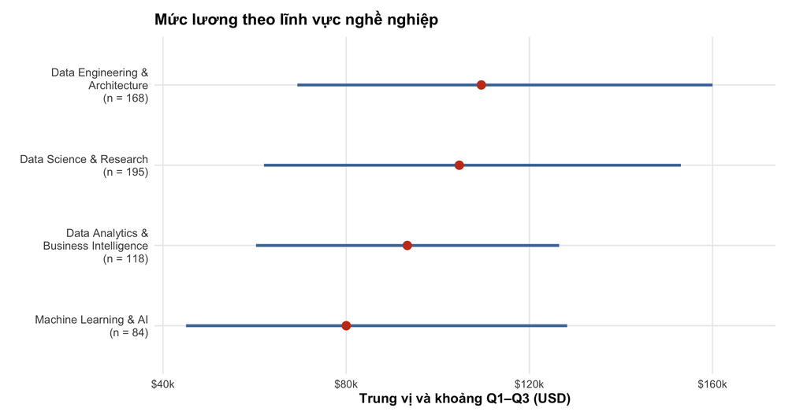

Trung vị và khoảng Q1–Q3 của mức lương theo lĩnh vực nghề nghiệp.

Trung vị giữa bốn lĩnh vực trải từ $80,020 ở Machine Learning & AI đến $109,512 ở Data Engineering & Architecture, tức chênh lệch khoảng $29,500. Tuy vậy, các khoảng Q1–Q3 chồng lấp rộng, nên phần trung tâm của bốn phân phối chưa tách biệt rõ như thứ hạng trung vị gợi ý. Riêng Machine Learning & AI có trung bình cao hơn trung vị khoảng $20,200 và độ phân tán lớn, cho thấy một số mức lương cao kéo trung bình lên trong khi phần giữa của phân phối vẫn thấp hơn. Chênh lệch theo lĩnh vực có thể phản ánh nhiệm vụ chuyên môn và nhu cầu thị trường, nhưng cũng phụ thuộc vào cơ cấu kinh nghiệm, khu vực và năm; vì vậy kết quả theo `job_field` cần được xem xét đồng thời với các đặc điểm này thay vì diễn giải riêng lẻ.

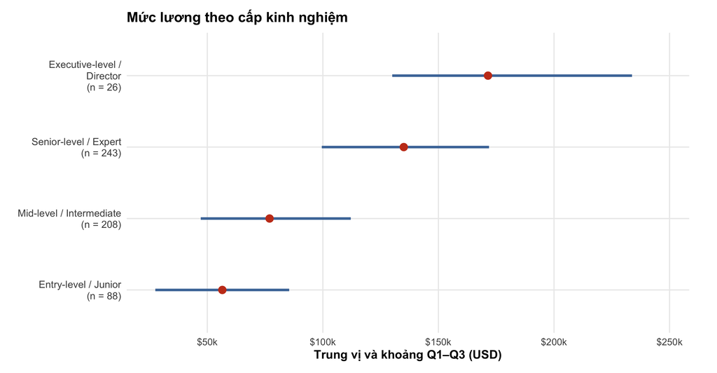

Trung vị và khoảng Q1–Q3 của mức lương theo cấp kinh nghiệm.

Trung vị lương tăng liên tục từ $56,500 ở Entry-level lên $76,940 ở Mid-level, $135,000 ở Senior và $171,438 ở Executive; bước tăng lớn nhất, khoảng $58,100, xuất hiện giữa Mid-level và Senior. Q3 của Entry-level ($85,426) vẫn thấp hơn Q1 của Senior ($99,532), cho thấy sự phân tầng lương giữa hai cấp này phản ánh dịch chuyển của phần trung tâm chứ không chỉ một vài mức lương cao. Khoảng Q1–Q3 của Executive rộng từ $130,006 đến $233,750 và nhóm chỉ có 26 quan sát, nên mức lương ở cấp cao nhất biến động lớn hơn và ước lượng trung tâm kém ổn định hơn. Mẫu hình tăng có thứ tự nhưng khoảng cách không đều cho thấy kinh nghiệm có liên hệ rõ với mức lương, đồng thời độ lớn chênh lệch cần được đặt trong cơ cấu nghề nghiệp của từng cấp.

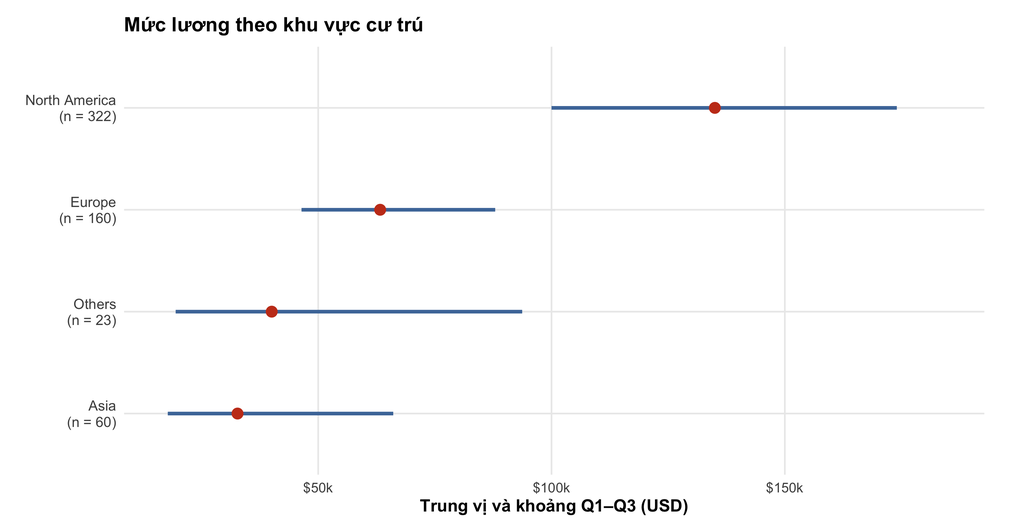

Trung vị và khoảng Q1–Q3 của mức lương theo khu vực cư trú.

North America có trung vị $135,000, cao hơn Europe khoảng $71,700 và gấp hơn bốn lần trung vị của Asia. Q1 của North America ($100,000) còn vượt Q3 của Europe ($87,932), cho thấy phần trung tâm của hai phân phối gần như tách biệt; giữa Europe và Asia, chênh lệch trung vị khoảng $30,600 nhưng hai khoảng Q1–Q3 vẫn chồng lấp. Khoảng cách này có thể phản ánh mặt bằng lương, cấu trúc thị trường lao động, cơ cấu nghề nghiệp và kinh nghiệm khác nhau giữa các khu vực, đồng thời mức lương USD chưa được điều chỉnh theo sức mua. Khu vực cư trú vì vậy có khả năng đóng góp đáng kể vào dự báo và cần được giữ trong mô hình cùng các biến nghề nghiệp; `Others` chỉ là nhóm tổng hợp của ba khu vực thưa, không đại diện cho một thị trường lao động đồng nhất.

## 19.4 Phân tích kết hợp

Phân tích kết hợp xem xét lĩnh vực nghề nghiệp theo cấp kinh nghiệm và khu vực cư trú theo hình thức làm việc. Hai biểu đồ cho phép đánh giá liệu chênh lệch quan sát được giữa các nhóm có duy trì giống nhau khi xét thêm đặc điểm đi kèm hay không.

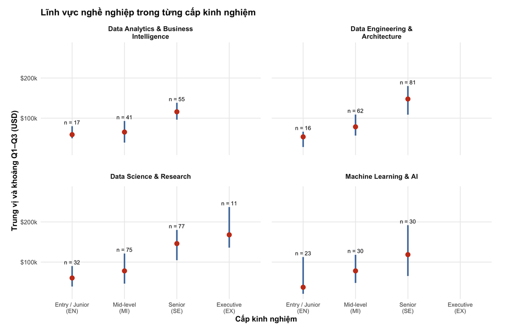

Trung vị và khoảng Q1–Q3 theo lĩnh vực nghề nghiệp và kinh nghiệm; chỉ gồm tổ hợp có n ≥ 10.

Ở Entry-level, Machine Learning & AI có trung vị khoảng $37,300, thấp hơn ba lĩnh vực còn lại ở mức $53,500–$60,400; đến Mid-level, nhóm này tăng lên khoảng $78,100 và gần bằng Data Science & Research cùng Data Engineering & Architecture. Tại Senior, hai lĩnh vực Data Science và Data Engineering đạt khoảng $146,000–$147,800, cao hơn Data Analytics và Machine Learning khoảng $27,000–$32,000, cho thấy khoảng cách giữa các lĩnh vực mở rộng trở lại ở cấp kinh nghiệm cao. Các khoảng Q1–Q3 vẫn chồng lấp, đặc biệt Machine Learning & AI có độ phân tán rộng; các quan sát Executive được phân tán giữa nhiều lĩnh vực nên cỡ mẫu của từng tổ hợp nhỏ hơn các cấp còn lại và phản ánh xu hướng ban đầu. Sự thay đổi cả thứ hạng lẫn độ lớn chênh lệch cho thấy mối liên hệ giữa lĩnh vực nghề nghiệp và mức lương không hoàn toàn đồng nhất giữa các cấp kinh nghiệm.

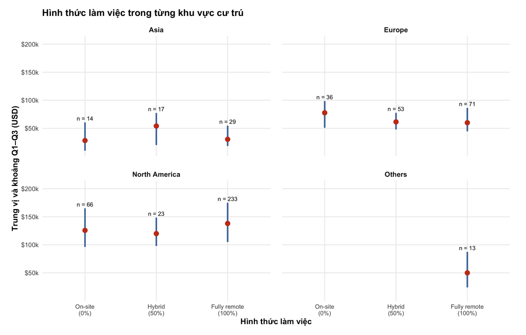

Trung vị và khoảng Q1–Q3 theo khu vực cư trú và hình thức làm việc; chỉ gồm tổ hợp có n ≥ 10.

Tại North America, Fully remote có trung vị $138,000, cao hơn On-site và Hybrid lần lượt khoảng $12,300 và $18,000; các khoảng Q1–Q3 vẫn chồng lấp rộng nên mức chênh lệch trong khu vực này tương đối hạn chế. Tại Europe, Fully remote có trung vị $60,000, thấp hơn On-site khoảng $17,700, trong khi tại Asia nhóm Hybrid cao hơn cả On-site và Fully remote khoảng $24,000–$26,000. Chiều của chênh lệch vì vậy thay đổi giữa các khu vực, trái với ấn tượng từ thống kê chung rằng Fully remote luôn gắn với mức lương cao hơn. Một số tổ hợp tại Asia và `Others` có cỡ mẫu nhỏ hơn, nên kết quả chủ yếu cho thấy mối liên hệ giữa hình thức làm việc và mức lương không đồng nhất giữa các khu vực.

## 19.5 Thay đổi mức lương theo thời gian

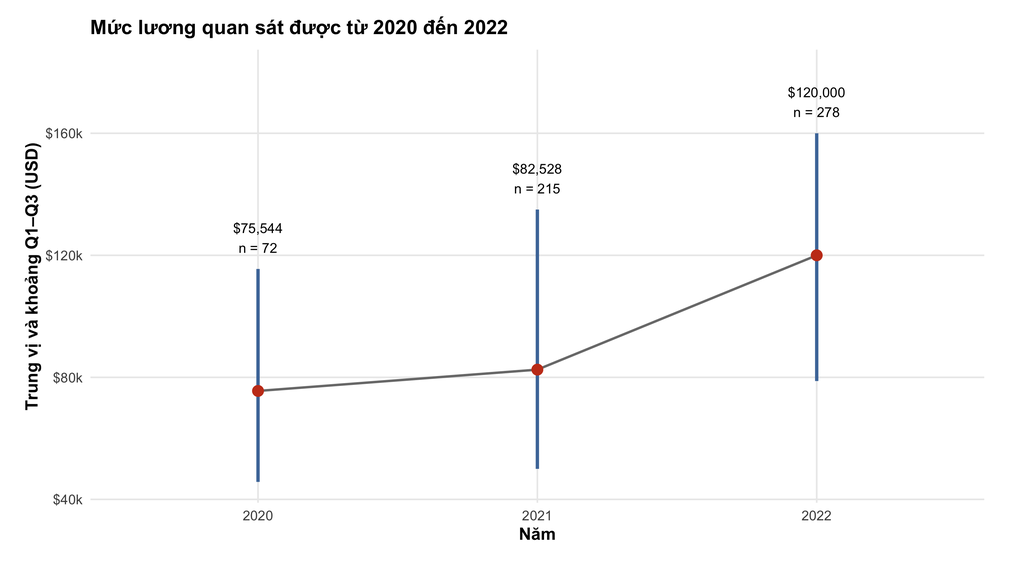

Trung vị và khoảng Q1–Q3 của mức lương theo năm quan sát.

Từ 2020 đến 2021, trung vị chỉ tăng khoảng $7,000 và trung bình tăng khoảng $3,600, trong khi hai khoảng Q1–Q3 chồng lấp rộng. Bước chuyển sang 2022 rõ hơn: trung vị tăng khoảng $37,500, trung bình tăng khoảng $23,700, đồng thời cả Q1 và Q3 đều dịch lên, gợi ý phần trung tâm của phân phối tăng chứ không chỉ xuất hiện thêm một vài mức lương cao. Tuy nhiên, năm 2022 chiếm gần một nửa mẫu và cơ cấu nghề nghiệp, kinh nghiệm, khu vực hoặc quy mô công ty có thể khác hai năm trước. Mức tăng không đều cho thấy ba năm nên được diễn giải như các thời kỳ rời rạc, không phải một xu hướng tuyến tính dài hạn.

Sau tiền xử lý, dữ liệu còn 565 quan sát, không có giá trị khuyết hoặc mã không hợp lệ; 42 dòng trùng hoàn toàn đã được loại. Phân phối lương lệch phải, nhưng IQR rộng cho thấy mức độ không đồng nhất đáng kể ngay trong 50% quan sát trung tâm. Mười ngoại lai theo quy tắc 1,5 × IQR không có dấu hiệu rõ ràng của lỗi nhập liệu nên được giữ nguyên trong dữ liệu.

Kinh nghiệm và khu vực cư trú tạo ra những dịch chuyển rõ nhất trong phần trung tâm của phân phối, trong khi quy mô công ty biểu hiện hiệu ứng ngưỡng giữa Small và Medium/Large. Chênh lệch theo lĩnh vực nghề nghiệp vừa nhỏ hơn vừa phụ thuộc vào cấp kinh nghiệm; tương tự, thứ tự lương giữa các hình thức làm việc đổi chiều theo khu vực. Bước tăng nổi bật ở năm 2022 cũng cho thấy biến thời gian không nên được giả định có quan hệ tuyến tính đơn giản với mức lương.

Các kết quả cho thấy kinh nghiệm, nghề nghiệp, quy mô công ty, hình thức làm việc, khu vực và năm đều có liên hệ với mức lương ở những mức độ khác nhau. Chênh lệch quan sát được giữa một số nhóm cũng thay đổi theo đặc điểm đi kèm. Tuy nhiên, các kết quả này chưa kiểm soát đồng thời các yếu tố và không cung cấp bằng chứng về quan hệ nhân quả. Vì vậy, các mô hình được xây dựng để xét đồng thời các biến dự báo và đánh giá khả năng dự báo ngoài mẫu.

# 20 Mục tiêu nghiên cứu

Trên cơ sở đặc điểm dữ liệu và các mẫu hình được nhận diện trong EDA, nghiên cứu tập trung vào hai mục tiêu chính.

**Mục tiêu 1 – Dự báo mức lương bằng các mô hình hồi quy.** Xây dựng và so sánh OLS, Ridge Regression và LASSO Regression trong dự báo mức lương, từ đó lựa chọn mô hình hồi quy có khả năng dự báo ngoài mẫu phù hợp nhất.

**Mục tiêu 2 – Đánh giá khả năng cải thiện dự báo bằng CatBoost.** Xây dựng CatBoost như một hướng mở rộng và đánh giá liệu mô hình này có cải thiện khả năng dự báo mức lương ngoài mẫu so với mô hình hồi quy được lựa chọn hay không.

# 21 Phương pháp nghiên cứu

## 21.1 Thiết kế và dữ liệu nghiên cứu

Nghiên cứu sử dụng phương pháp định lượng nhằm xây dựng và so sánh các mô hình dự báo mức lương trong lĩnh vực khoa học dữ liệu. Dữ liệu mang tính quan sát, vì vậy kết quả được diễn giải dưới góc độ dự báo và mối liên hệ thống kê, không được xem là bằng chứng về quan hệ nhân quả.

Dữ liệu sau tiền xử lý gồm 565 quan sát và không có giá trị khuyết. `salary_in_usd` là biến mục tiêu định lượng liên tục; mười ngoại lai được giữ lại và sử dụng như các quan sát khác.

Tập biến dự báo gồm `work_year`, `experience_level`, `employment_group`, `job_field`, `remote_ratio`, `company_size`, `employee_region` và `same_country`; tất cả được xử lý như biến phân loại. `job_field` là biến nghề nghiệp dùng chung cho bốn mô hình, còn `job_title_standardized` chỉ phục vụ đối chiếu và diễn giải. `salary` và `salary_currency` không được sử dụng vì chứa thông tin trực tiếp tạo nên biến mục tiêu, có thể gây rò rỉ thông tin. Mô hình chính không bổ sung thành phần tương tác.

## 21.2 Câu hỏi nghiên cứu

Các câu hỏi nghiên cứu bám sát hai mục tiêu đã xác định và tập trung vào khả năng dự báo mức lương ngoài mẫu.

**Câu hỏi nghiên cứu 1:**  
Giữa OLS, Ridge Regression và LASSO Regression, mô hình nào có khả năng dự báo mức lương ngoài mẫu phù hợp nhất?

**Câu hỏi nghiên cứu 2:**  
CatBoost có cải thiện khả năng dự báo mức lương ngoài mẫu so với mô hình hồi quy được lựa chọn hay không?

Các câu hỏi được trả lời chủ yếu bằng RMSE trên validation set; MAE, MAPE và R² được sử dụng để bổ sung cho việc diễn giải kết quả.

## 21.3 Quy trình xây dựng và đánh giá mô hình

Các biến phân loại, thứ tự mức và nhóm tham chiếu được xác định trước theo quy tắc tiền xử lý và ý nghĩa nội dung, không dựa trên giá trị của biến mục tiêu. Sau đó, dữ liệu được chia ngẫu nhiên thành 80% training set và 20% validation set với `random seed` cố định. Mọi bước ước lượng hệ số, lựa chọn lambda và điều chỉnh siêu tham số chỉ được thực hiện trong training set; validation set không tham gia vào quá trình học mô hình và chỉ được sử dụng để đánh giá ngoài mẫu.

OLS được sử dụng làm mô hình nền và không yêu cầu điều chỉnh siêu tham số chính. Lambda của Ridge Regression và LASSO Regression, cùng các siêu tham số của CatBoost, được lựa chọn bằng cross-validation trong training set. Sau khi xác định cấu hình phù hợp, các mô hình được huấn luyện trên toàn bộ training set và đánh giá trên cùng validation set bằng RMSE, MAE, MAPE và R² (James et al., 2021).

## 21.4 Mô hình nghiên cứu

**OLS.** OLS được sử dụng làm mô hình nền để biểu diễn mức lương dự báo từ tổ hợp tuyến tính của các biến đầu vào. Do các biến dự báo đều là biến phân loại, chúng được chuyển thành biến giả và mỗi biến có một mức tham chiếu. Hệ số ước lượng thể hiện chênh lệch mức lương dự kiến giữa một nhóm và mức tham chiếu khi giữ các đặc điểm còn lại cố định; kết quả này không được diễn giải như quan hệ nhân quả (James et al., 2021).

$$y_i = \beta_0 + \sum_{j=1}^{p} \beta_j x_{ij} + \varepsilon_i.$$

Trong đó, $y_i$ là mức lương của quan sát $i$, $x_{ij}$ là các biến dự báo sau mã hóa, $\beta_j$ là các hệ số hồi quy và $\varepsilon_i$ là sai số. OLS có cấu trúc dễ diễn giải nhưng có thể nhạy với đa cộng tuyến, phương sai sai số không đồng nhất và các quan sát có phần dư lớn; các giả định và chẩn đoán phù hợp sẽ được kiểm tra sau khi mô hình được xây dựng (James et al., 2021).

**Ridge Regression.** Ridge Regression mở rộng hồi quy tuyến tính bằng cách bổ sung khoản phạt L2 vào hàm mất mát. Khoản phạt làm co các hệ số về gần 0 nhưng thường không đưa chúng về đúng 0, qua đó giúp kiểm soát độ lớn hệ số và giảm độ nhạy trước sự phụ thuộc giữa các biến dự báo. Mức điều chuẩn được kiểm soát bởi tham số $\lambda$ (James et al., 2021; Hastie et al., 2009).

$$\min_{\boldsymbol{\beta}} \left[\mathrm{RSS} + \lambda
\sum_{j=1}^{p}\beta_j^2\right].$$

Lambda càng lớn thì mức co hệ số càng mạnh; `lambda` được lựa chọn bằng 10-fold cross-validation trong training set.

**LASSO Regression.** LASSO Regression sử dụng khoản phạt L1. Ngoài việc co hệ số, phương pháp có thể đưa một số hệ số về đúng 0 và tạo mô hình thưa hơn. Với dữ liệu factor, quá trình này diễn ra trên từng biến dummy sau mã hóa; một dummy bằng 0 không đồng nghĩa toàn bộ factor bị loại khỏi mô hình (James et al., 2021; Hastie et al., 2015).

$$\min_{\boldsymbol{\beta}} \left[\mathrm{RSS} + \lambda
\sum_{j=1}^{p}|\beta_j|\right].$$

Lambda của LASSO Regression được lựa chọn bằng 10-fold cross-validation trong training set theo mục tiêu giảm sai số dự báo.

**CatBoost.** CatBoost thuộc nhóm tăng cường theo gradient (*gradient boosting*) trên cây quyết định và xây dựng các cây theo trình tự. Mỗi cây bổ sung tập trung cải thiện phần sai số còn lại của tập hợp trước đó; dự báo cuối cùng là tổng đóng góp của các cây (Prokhorenkova et al., 2018).

$$F_M(\mathbf{x}) = \sum_{m=1}^{M} \eta h_m(\mathbf{x}).$$

Trong đó, $h_m(\mathbf{x})$ là cây thứ $m$, $\eta$ là *learning rate* (tốc độ học), $M$ là số cây và $F_M(\mathbf{x})$ là dự báo cuối cùng.

CatBoost nhận các biến phân loại ở dạng gốc và thực hiện chuyển đổi chúng bên trong thuật toán. Vì vậy, không cần tạo thủ công một biến nhị phân cho mọi mức của toàn bộ biến phân loại trước khi huấn luyện; thuật toán vẫn thực hiện quá trình xử lý và mã hóa nội bộ (Prokhorenkova et al., 2018; CatBoost, n.d.).

Với *ordered statistics* (thống kê theo thứ tự), các thống kê dựa trên biến mục tiêu được tính theo một thứ tự ngẫu nhiên mà không dùng thông tin của một quan sát để tạo đặc trưng cho chính quan sát đó. *Ordered boosting* (boosting theo thứ tự) áp dụng nguyên tắc tương tự khi xây dựng mô hình. Hai kỹ thuật được đề xuất nhằm hạn chế rò rỉ biến mục tiêu và giảm *prediction shift* (dịch chuyển dự báo), nhưng không hàm ý các vấn đề này bị loại bỏ hoàn toàn trong mọi dữ liệu (Prokhorenkova et al., 2018).

CatBoost được sử dụng như một mô hình mở rộng vì dữ liệu có nhiều biến phân loại và thuật toán có thể xử lý các biến này trong quá trình huấn luyện. Mô hình được triển khai bằng thư viện CatBoost mã nguồn mở dành cho R (CatBoost, n.d.).

## 21.5 Tiêu chí đánh giá và khả năng tái lập

**RMSE — căn bậc hai của sai số bình phương trung bình.** RMSE là tiêu chí chính và nhạy hơn với các sai số dự báo lớn.

$$\mathrm{RMSE} =
\sqrt{\frac{1}{n}\sum_{i=1}^{n}\left(y_i-\hat{y}_i\right)^2}.$$

**MAE — sai số tuyệt đối trung bình.** MAE phản ánh độ lớn tuyệt đối trung bình của sai số và có cùng đơn vị với mức lương.

$$\mathrm{MAE} = \frac{1}{n}\sum_{i=1}^{n}\left|y_i-\hat{y}_i\right|.$$

**MAPE — sai số phần trăm tuyệt đối trung bình.** MAPE phản ánh độ lớn trung bình của sai số tuyệt đối theo tỷ lệ phần trăm so với mức lương thực tế.

$$\mathrm{MAPE} =
\frac{100}{n}\sum_{i=1}^{n}\left|\frac{y_i-\hat{y}_i}{y_i}\right|.$$

MAPE không có đơn vị và được biểu thị bằng phần trăm, qua đó bổ sung thông tin về quy mô sai số tương đối giữa các quan sát có mức lương khác nhau. Chỉ số có thể trở nên rất lớn khi mức lương thực tế thấp vì giá trị thực nằm ở mẫu số; do đó, MAPE chỉ được sử dụng như chỉ số bổ sung và không phải tiêu chí chính để lựa chọn mô hình. Trong bộ dữ liệu hiện tại, `salary_in_usd` không có giá trị bằng 0 nên MAPE được xác định cho toàn bộ quan sát trong validation set.

**R² — hệ số xác định.** R² cho biết mức độ biến thiên của mức lương được mô hình giải thích trên dữ liệu đánh giá. Khi được tính trên validation set trong báo cáo này, giá trị trung bình ở mẫu số là mức lương trung bình thực tế của validation set; vì vậy, R² so sánh mô hình với phương án dùng giá trị trung bình này làm dự báo cho mọi quan sát. R² trên validation set có thể nhận giá trị âm khi tổng sai số bình phương của mô hình lớn hơn tổng sai lệch của mức lương thực tế quanh giá trị trung bình của validation set.

$$R^2 = 1 -
\frac{\sum_{i=1}^{n}\left(y_i-\hat{y}_i\right)^2}{\sum_{i=1}^{n}\left(y_i-\bar{y}\right)^2}.$$

Mô hình có RMSE ngoài mẫu thấp nhất được ưu tiên. MAE, MAPE và R² được sử dụng để kiểm tra tính nhất quán của kết quả; nếu các thước đo dẫn đến thứ tự khác nhau, nghiên cứu sẽ trình bày sự đánh đổi thay vì lựa chọn dựa trên một chỉ số duy nhất (James et al., 2021).

Toàn bộ phân tích được thực hiện trong R với `random seed` cố định. Phiên bản R và các gói sử dụng được ghi nhận tại thời điểm xây dựng mô hình; quy tắc tiền xử lý và cách chia dữ liệu được giữ nhất quán cho bốn mô hình. Mã lệnh và kết quả được lưu theo cấu trúc thư mục của dự án. Phiên bản gói CatBoost cũng được ghi nhận khi thực hiện mô hình (CatBoost, n.d.).

# 22 Xây dựng và đánh giá các mô hình hồi quy

## 22.1 Chuẩn bị dữ liệu và hồ sơ tham chiếu

Bộ dữ liệu mô hình gồm 565 quan sát, với `salary_in_usd` là biến mục tiêu. Tám biến dự báo gồm `work_year`, `experience_level`, `employment_group`, `job_field`, `remote_ratio`, `company_size`, `employee_region` và `same_country`; `salary`, `salary_currency`, `job_title_standardized` và thành phần tương tác không được sử dụng. `employment_group` được sử dụng thay cho `employment_type` vì Part-time, Contract và Freelance đã được gộp thành Other employment arrangements để giảm các mức quá thưa; hai biến không được đưa đồng thời vào mô hình vì chứa thông tin trùng lặp.

Nghiên cứu giữ `salary_in_usd` trên thang đo gốc. Cách lựa chọn này giúp hệ số hồi quy, mức lương dự kiến, RMSE và MAE được diễn giải trực tiếp bằng USD, phù hợp với mục tiêu dự báo và giải thích kết quả của báo cáo. Mặc dù mức lương có phân phối lệch phải, các giá trị cao đã được kiểm tra và chưa cho thấy dấu hiệu rõ ràng của lỗi dữ liệu, vì vậy chúng tiếp tục được giữ lại như các quan sát hợp lệ. Độ lệch phải và các mức lương cao có thể làm phần dư có đuôi nặng và khiến RMSE nhạy hơn với một số sai số lớn; đây là giới hạn cần lưu ý khi đánh giá mô hình, thay vì được xử lý bằng biến đổi log trong đặc tả chính. Biến đổi log có thể được xem xét trong một phân tích độ nhạy riêng nếu cần, nhưng dự báo khi đó phải được chuyển ngược về USD và đánh giá trên cùng thang đo gốc để bảo đảm khả năng so sánh.

```r
predictor_names <- c(
  "work_year", "experience_level", "employment_group",
  "job_field", "remote_ratio", "company_size",
  "employee_region", "same_country"
)

model_data <- data_eda |>
  select(salary_in_usd, all_of(predictor_names)) |>
  mutate(
    work_year = factor(work_year, levels = c("2020", "2021", "2022")),
    experience_level = factor(experience_level, levels = c(
      "Entry-level / Junior", "Mid-level / Intermediate",
      "Senior-level / Expert", "Executive-level / Director"
) ),
    employment_group = factor(employment_group, levels = c(
      "Full-time", "Other employment arrangements"
) ),
    job_field = factor(job_field, levels = c(
      "Data Science & Research", "Data Engineering & Architecture",
      "Data Analytics & Business Intelligence", "Machine Learning & AI"
) ),
    remote_ratio = factor(remote_ratio, levels = c(
      "On-site (0%)", "Hybrid (50%)", "Fully remote (100%)"
) ),
    company_size = factor(company_size, levels = c("Small", "Medium", "Large")),
    employee_region = factor(employee_region, levels = c(
      "North America", "Europe", "Asia", "Others"
) ),
    same_country = factor(same_country, levels = c(
      "Cùng quốc gia", "Khác quốc gia"
) )
)

reference_levels <- data.frame(
  Variable = predictor_names,
  Reference_level = vapply(
    model_data[predictor_names],
    function(x) levels(x)[1],
    character(1)
  ),
  row.names = NULL
)

print(reference_levels)
```

```
##           Variable         Reference_level
## 1        work_year                    2020
## 2 experience_level    Entry-level / Junior
## 3 employment_group               Full-time
## 4        job_field Data Science & Research
## 5     remote_ratio            On-site (0%)
## 6     company_size                   Small
## 7  employee_region           North America
## 8     same_country           Cùng quốc gia
```

Tám mức trên hợp thành hồ sơ tham chiếu của mô hình. Hệ số chặn OLS là mức lương dự kiến của một hồ sơ đồng thời thuộc toàn bộ các mức tham chiếu này. Mỗi hệ số biến giả thể hiện phần chênh lệch khi thay đổi mức tương ứng và giữ các đặc điểm còn lại cố định.

```r
analysis_seed <- 20260729
set.seed(analysis_seed)

train_index <- sample(
  seq_len(nrow(model_data)),
  size = floor(0.8 * nrow(model_data))
)

train <- model_data[train_index, ]
validation <- model_data[-train_index, ]

foldid <- sample(
  rep(1:10, length.out = nrow(train))
)

nrow(train)
```

```
## [1] 452
```

```r
nrow(validation)
```

```
## [1] 113
```

Training set gồm 452 quan sát và được sử dụng để ước lượng mô hình cùng lựa chọn `lambda`; validation set gồm 113 quan sát và được giữ độc lập để đánh giá ngoài mẫu. OLS, Ridge Regression và LASSO Regression sử dụng cùng phép chia dữ liệu; hai mô hình điều chuẩn cũng sử dụng cùng các phần dữ liệu trong 10-fold cross-validation để kết quả có thể so sánh trực tiếp.

## 22.2 Hồi quy tuyến tính bội bằng OLS

```r
model_formula <- salary_in_usd ~
  work_year +
  experience_level +
  employment_group +
  job_field +
  remote_ratio +
  company_size +
  employee_region +
  same_country

ols_model <- lm(
  model_formula,
  data = train
)

summary(ols_model)
```

```
##
## Call:
## lm(formula = model_formula, data = train)
##
## Residuals:
##     Min      1Q  Median      3Q     Max
## -129243  -28821   -7265   21057  357247
##
## Coefficients:
##                                                 Estimate Std. Error t value
## (Intercept)                                     123909.1    13278.4   9.332
## work_year2021                                   -12654.3     8459.1  -1.496
## work_year2022                                   -10731.8     9038.8  -1.187
## experience_levelMid-level / Intermediate         18651.2     8138.7   2.292
## experience_levelSenior-level / Expert            45462.3     8410.5   5.405
## experience_levelExecutive-level / Director      120497.5    13813.0   8.723
## employment_groupOther employment arrangements     5899.5    14281.7   0.413
## job_fieldData Engineering & Architecture         -5509.2     6473.8  -0.851
## job_fieldData Analytics & Business Intelligence -36174.7     7349.8  -4.922
## job_fieldMachine Learning & AI                    3837.0     8026.0   0.478
## remote_ratioHybrid (50%)                         -8365.2     9201.9  -0.909
## remote_ratioFully remote (100%)                    365.2     6601.8   0.055
## company_sizeMedium                                 747.6     9001.4   0.083
## company_sizeLarge                                16144.4     8666.6   1.863
## employee_regionEurope                           -68879.1     6852.2 -10.052
## employee_regionAsia                             -85005.0     9735.3  -8.732
## employee_regionOthers                           -80870.2    13585.8  -5.953
## same_countryKhác quốc gia                         2659.7     9616.9   0.277
##                                                             Pr(>|t|)
## (Intercept)                                     < 0.0000000000000002 ***
## work_year2021                                                 0.1354
## work_year2022                                                 0.2358
## experience_levelMid-level / Intermediate                      0.0224 *
## experience_levelSenior-level / Expert                  0.00000010692 ***
## experience_levelExecutive-level / Director      < 0.0000000000000002 ***
## employment_groupOther employment arrangements                 0.6797
## job_fieldData Engineering & Architecture                      0.3952
## job_fieldData Analytics & Business Intelligence        0.00000121981 ***
## job_fieldMachine Learning & AI                                0.6328
## remote_ratioHybrid (50%)                                      0.3638
## remote_ratioFully remote (100%)                               0.9559
## company_sizeMedium                                            0.9338
## company_sizeLarge                                             0.0632 .
## employee_regionEurope                           < 0.0000000000000002 ***
## employee_regionAsia                             < 0.0000000000000002 ***
## employee_regionOthers                                  0.00000000545 ***
## same_countryKhác quốc gia                                     0.7822
## ---
## Signif. codes:  0 '***' 0.001 '**' 0.01 '*' 0.05 '.' 0.1 ' ' 1
##
## Residual standard error: 53540 on 434 degrees of freedom
## Multiple R-squared:  0.489,  Adjusted R-squared:  0.469
## F-statistic: 24.43 on 17 and 434 DF,  p-value: < 0.00000000000000022
```

Sau khi đồng thời xét năm làm việc, nhóm tuyển dụng, lĩnh vực nghề nghiệp, hình thức làm việc, quy mô công ty và đặc điểm địa lý, cấp kinh nghiệm có mối liên hệ rõ với mức lương. So với nhóm người lao động có cấp kinh nghiệm Entry-level / Junior, mức lương dự kiến của nhóm người lao động có cấp kinh nghiệm Mid-level / Intermediate cao hơn khoảng $18,651, nhóm người lao động có cấp kinh nghiệm Senior-level / Expert cao hơn khoảng $45,462 và nhóm người lao động có cấp kinh nghiệm Executive-level / Director cao hơn khoảng $120,498. Cả ba chênh lệch đều có p-value dưới 0,05, trong đó mức chênh lệch của nhóm người lao động có cấp kinh nghiệm Executive-level / Director là lớn nhất.

Khu vực cư trú gắn với chênh lệch lớn sau khi đồng thời xét các biến còn lại. So với người lao động cư trú tại Bắc Mỹ (North America), mức lương dự kiến của người lao động cư trú tại châu Âu (Europe) thấp hơn khoảng $68,879, tại châu Á (Asia) thấp hơn khoảng $85,005 và tại nhóm khu vực khác (Others) thấp hơn khoảng $80,870. Các chênh lệch này đều có p-value dưới 0,05. Đối với lĩnh vực nghề nghiệp, nhóm ngành Data Analytics & Business Intelligence có mức lương dự kiến thấp hơn nhóm ngành Data Science & Research khoảng $36,175; hai nhóm ngành Data Engineering & Architecture và Machine Learning & AI chưa cho thấy chênh lệch rõ so với nhóm tham chiếu.

Kết quả chưa cho thấy chênh lệch rõ theo năm làm việc, nhóm tuyển dụng, hình thức làm việc, trạng thái làm việc cùng quốc gia và một số mức quy mô công ty. Các biến này vẫn được giữ trong mô hình vì chúng đã được xác định trước từ nội dung nghiên cứu và nghiên cứu tập trung vào dự báo, không lựa chọn biến chỉ dựa trên p-value của training set. Ngoài ra, việc một mức riêng lẻ chưa có ý nghĩa thống kê không đồng nghĩa toàn bộ biến phân loại không cung cấp thông tin.

```r
reference_profile <- data.frame(
  work_year = factor("2020", levels = levels(train$work_year)),
  experience_level = factor(
    "Entry-level / Junior",
    levels = levels(train$experience_level)
  ),
  employment_group = factor(
    "Full-time",
    levels = levels(train$employment_group)
  ),
  job_field = factor(
    "Data Science & Research",
    levels = levels(train$job_field)
  ),
  remote_ratio = factor(
    "On-site (0%)",
    levels = levels(train$remote_ratio)
  ),
  company_size = factor("Small", levels = levels(train$company_size)),
  employee_region = factor(
    "North America",
    levels = levels(train$employee_region)
  ),
  same_country = factor(
    "Cùng quốc gia",
    levels = levels(train$same_country)
  )
)

executive_profile <- reference_profile
executive_profile$experience_level <- factor(
  "Executive-level / Director",
  levels = levels(train$experience_level)
)

europe_profile <- reference_profile
europe_profile$employee_region <- factor(
  "Europe",
  levels = levels(train$employee_region)
)

analytics_profile <- reference_profile
analytics_profile$job_field <- factor(
  "Data Analytics & Business Intelligence",
  levels = levels(train$job_field)
)

profile_predictions <- c(
  Reference = unname(predict(ols_model, newdata = reference_profile)),
  Executive = unname(predict(ols_model, newdata = executive_profile)),
  Europe = unname(predict(ols_model, newdata = europe_profile)),
  Data_Analytics_BI = unname(predict(ols_model, newdata = analytics_profile))
)

profile_predictions
```

```
##         Reference         Executive            Europe Data_Analytics_BI
##         123909.12         244406.67          55029.99          87734.46
```

Hồ sơ tham chiếu đại diện cho một vị trí trong năm 2020, dành cho người lao động có cấp kinh nghiệm Entry-level / Junior, làm việc toàn thời gian trong nhóm ngành Data Science & Research, theo hình thức On-site tại công ty có quy mô nhỏ, cư trú ở Bắc Mỹ và làm việc cho công ty cùng quốc gia. Mô hình OLS dự báo mức lương của hồ sơ này là $123,909. Đây là giá trị nền được ước lượng cho tổ hợp tham chiếu, không phải mức lương trung bình của toàn bộ mẫu hoặc của một nhóm riêng lẻ.